# Базовая модель экономического роста

Математическое моделирование

Александрова УВ

Российский университет дружбы народов, Москва, Россия

21 марта 2025

# Информация

## Докладчик

- Александрова Ульяна
- студентка 3го курса
- Факультет физико-математических и естественных наук
- Российский университет дружбы народов
- 1132226444@rudn.ru

[figure not shown]

# Основные аспекты экономического роста

**Экономический рост** — это увеличение или улучшение экономики, скорректированной на инфляцию, в течение финансового года [1].

**Измерение роста**:

- Экономический рост измеряется с использованием национальных счетов доходов.
- Реальный ВВП на душу населения;
- Интенсивный рост;
- Экстенсивный рост;
- Долгосрочный рост;
- Краткосрочные изменения;

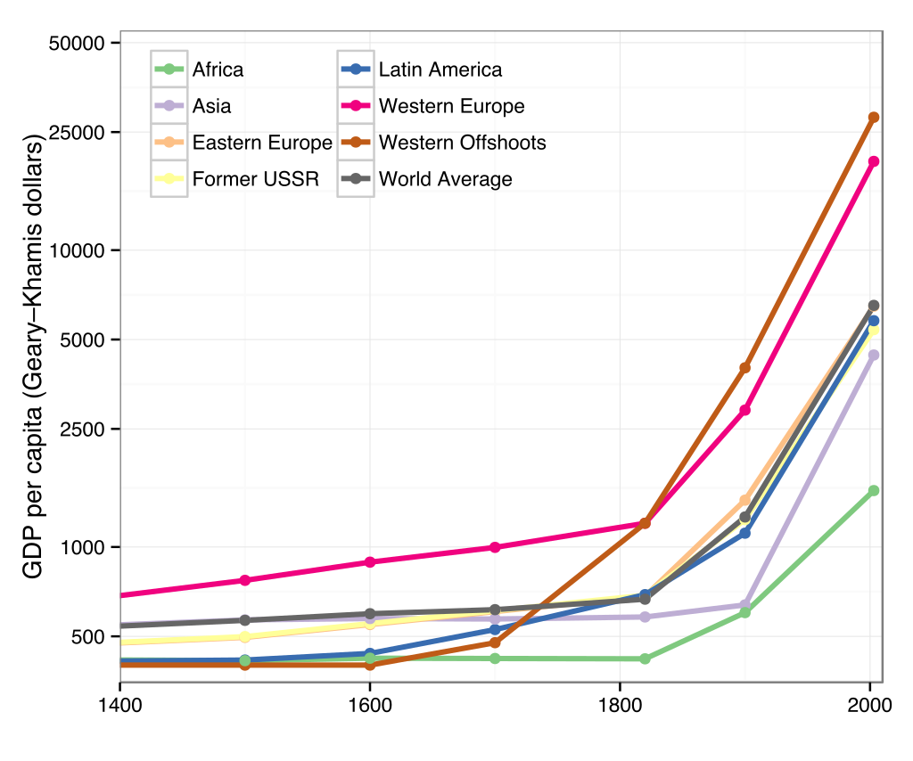

Исторический мировой ВВП на душу населения [1]

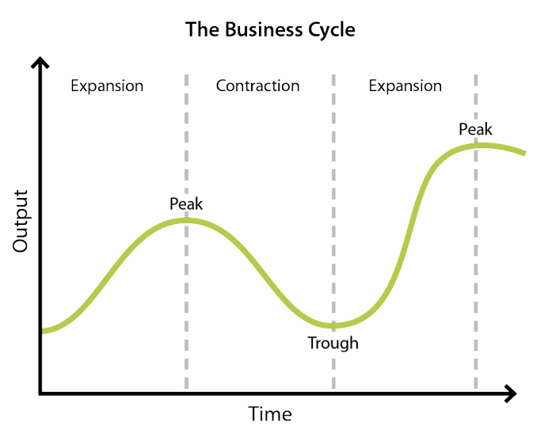

Бизнесс-цикл [4]

**Бизнес-цикл**, также известный как экономический цикл, представляет собой периодические колебания уровня экономической активности в стране или регионе. Эти колебания включают периоды роста (подъема) и спада (рецессии) в экономике.

## Базовая Модель

**Базовая модель экономического роста** описывает, как изменяется количество производимых товаров и услуг с течением времени. Этот показатель обычно измеряется в процентах от валового внутреннего продукта (ВВП)

## Применение модели

1. Анализ экономического роста стран;
2. Планирование инвестиций;
3. Оценка влияния политики.

## Факторы роста

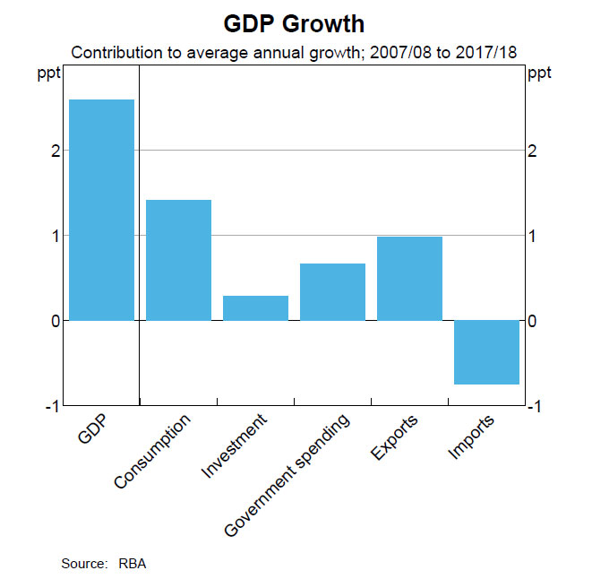

Основные факторы роста и их влияние на рост экономики [4]

1. Технологический прогресс
2. Инвестиции
3. Человеческий капитал
4. Институциональные факторы
5. Демографические факторы

# Построение модели

## Постановка задачи

Модель включает следующие параметры:

- *L*<sub>*t*</sub> — труд работников в момент времени *t*;
- *M*<sub>*t*</sub> — труд машин в момент времени *t*;
- *O*<sub>*t*</sub> — выходное значение модели (объем производства) в момент времени *t*;
- *E*<sub>*t*</sub> — потребленные ресурсы в момент времени *t*;
- *I*<sub>*t*</sub> — инвестиции в момент времени *t*;
- *s* — ставка сбережений (доля дохода, направляемая на инвестиции);
- *d* — норма амортизации (износ капитала).

## Выход модели (объем производства)

$$O_t = \sqrt{L_t \cdot M_t}.$$

## Инвестиции и потребление

*I*<sub>*t*</sub> = *s* ⋅ *O*<sub>*t*</sub>,

где *s* — ставка сбережений.

Потребление ресурсов *E*<sub>*t*</sub> связано с объемом производства следующим образом:

*O*<sub>*t*</sub> = *E*<sub>*t*</sub> + *I*<sub>*t*</sub>.

## Динамика машинного труда

*M*<sub>*t* + 1</sub> = *M*<sub>*t*</sub> + *I*<sub>*t*</sub> − *d* ⋅ *M*<sub>*t*</sub>,

где: - *I*<sub>*t*</sub> — инвестиции, увеличивающие машинный труд; - *d* ⋅ *M*<sub>*t*</sub> — амортизация, уменьшающая машинный труд.

## Динамика труда человека

*L*<sub>*t* + 1</sub> = (1 + *n*) ⋅ *L*<sub>*t*</sub>.

Для простоты будем считать, что *n* = 0, то есть труд человека постоянен: *L*<sub>*t*</sub> = *L*<sub>0</sub>.

## Устойчивое состояние модели

*I*<sub>*t*</sub> = *d* ⋅ *M*<sub>*t*</sub>.

Подставляя выражение для инвестиций *I*<sub>*t*</sub> = *s* ⋅ *O*<sub>*t*</sub>, получаем:

*s* ⋅ *O*<sub>*t*</sub> = *d* ⋅ *M*<sub>*t*</sub>.

С учетом производственной функции $O_t = \sqrt{L_t \cdot M_t}$, это уравнение позволяет определить устойчивый уровень машинного труда *M** и объема производства *O**:

$$s \cdot \sqrt{L_t \cdot M^*} = d \cdot M^*.$$

Решая это уравнение, находим:

$$M^* = \frac{s^2 \cdot L_t}{d^2}.$$

Соответственно, устойчивый объем производства:

$$O^* = \sqrt{L_t \cdot M^*} = \frac{s \cdot L_t}{d}.$$

## Пример численного анализа

- *L*<sub>*t*</sub> = 100 (постоянный труд человека);
- *s* = 0.3 (ставка сбережений 30%);
- *d* = 0.1 (норма амортизации 10%).

Устойчивый уровень машинного труда:

$$M^* = \frac{0.3^2 \cdot 100}{0.1^2} = \frac{9}{0.01} = 900.$$

Устойчивый объем производства:

$$O^* = \frac{0.3 \cdot 100}{0.1} = 300.$$

## Реализация модели на Python

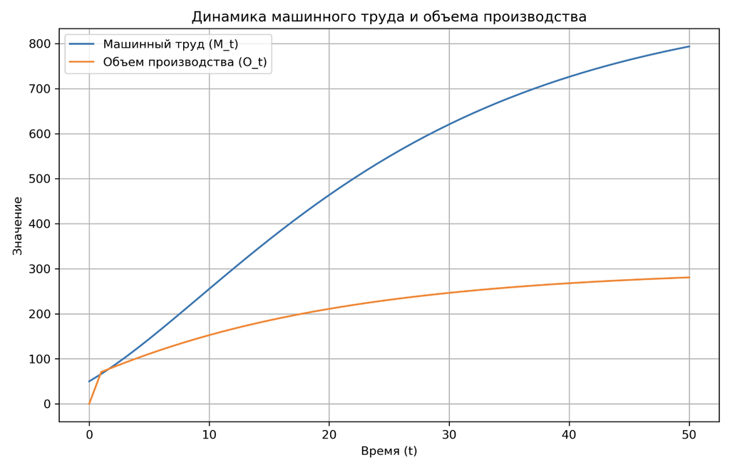

Базовая Модель Экономического Роста

# Улучшение модели

1. Включение технологического прогресса

$$O_t = A_t \cdot \sqrt{L_t \cdot M_t}$$

2. Учет человеческого капитала

$$O_t = \sqrt{L_t \cdot M_t \cdot
H_t}$$

3. Введение демографических факторов

$$O_t = \sqrt{L_t \cdot M_t \cdot
P_t}$$

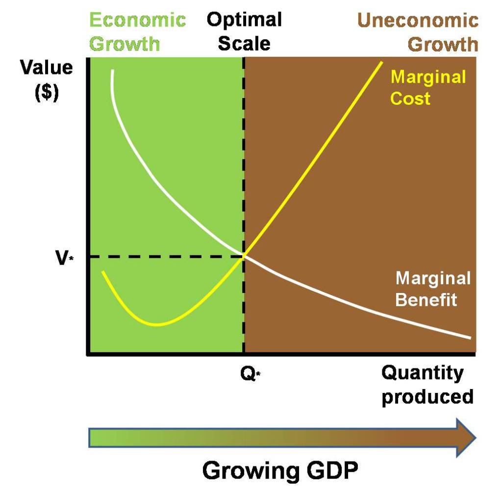

Влияние экологических факторов на рост экономики [1]

4. Экологические факторы

$$O_t = \sqrt{L_t \cdot M_t \cdot E_t}$$

5. Учет международной торговли

$$O_t = \sqrt{L_t \cdot M_t \cdot (X_t - M_t)}$$

# Выводы

Базовая модель экономического роста является важным инструментом для анализа и прогнозирования экономического развития. Она помогает понять, как различные факторы, такие как труд, инвестиции и амортизация, влияют на производство товаров и услуг. Современные модели экономического роста включают в себя множество факторов, что позволяет более точно прогнозировать развитие экономики и учитывать влияние различных факторов на экономический рост.

# Источники литературы

1. [Economic growth. Wikipedia](https://en.wikipedia.org/wiki/Economic_growth#Unified_growth_theory)
2. [Основные модели экономического роста](https://spravochnick.ru/ekonomika/osnovnye_modeli_ekonomicheskogo_rosta/)
3. [Экономический рост. Модели экономического роста](https://cyberleninka.ru/article/n/ekonomicheskiy-rost-modeli-ekonomicheskogo-rosta)
4. [Reserve Bank Of Australia](https://www.rba.gov.au/education/resources/explainers/economic-growth.html)
5. Модель Солоу